# DATA 624 | Predictive Analytics

Gabriella Martinez

2022-04-24

# Homework 8: Non-Linear Regression

## Instructions

In Kuhn and Johnson do problems 7.2 and 7.5. There are only two but they consist of many parts. Please submit a link to your Rpubs and submit the .rmd file as well.

## Packages

```r
library(AppliedPredictiveModeling)
library(dplyr)
library(forecast)
library(ggplot2)
library(tidyr)
library(mice)
library(corrplot)
library(MASS)
library(mlbench)
library(caret)
library(earth)
library(RANN)
```

### 7.2

**Friedman (1991) introduced several benchmark data sets create by simulation. One of these simulations used the following nonlinear equation to create data:**

$y = 10 sin(\pi x_1x_2) + 20(x_3 − 0.5)^2 + 10x_4 + 5x_5 + N(0, \sigma^2)$

**where the x values are random variables uniformly distributed between [0, 1] (there are also 5 other non-informative variables also created in the simulation). The package mlbench contains a function called mlbench.friedman1 that simulates these data:**

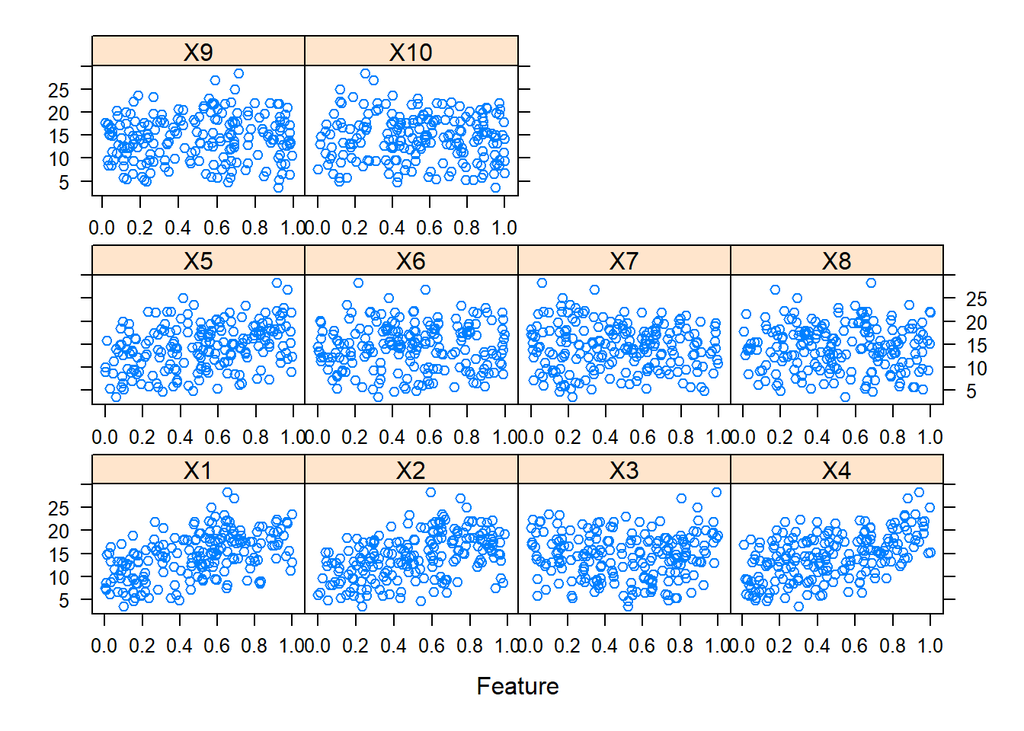

```r
set.seed(200)

trainingData = mlbench.friedman1(200, sd = 1)
## We convert the 'x' data from a matrix to a data frame
## One reason is that this will give the columns names.
trainingData$x = data.frame(trainingData$x)
## Look at the data using
featurePlot(trainingData$x, trainingData$y)
```

```r
## or other methods.
```

```r
## This creates a list with a vector 'y' and a matrix
## of predictors 'x'. Also simulate a large test set to
## estimate the true error rate with good precision:
testData = mlbench.friedman1(5000, sd = 1)
testData$x = data.frame(testData$x)
```

**(a) Tune several models on these data.**

**For example:**

```r
knnModel <- train(x = trainingData$x, y = trainingData$y,
                  method = "knn",
                  preProc = c("center", "scale"),
                  tuneLength = 10)

knnPred <- predict(knnModel, newdata = testData$x)
postResample(pred = knnPred, obs = testData$y)
```

```
##      RMSE  Rsquared       MAE
## 3.2040595 0.6819919 2.5683461
```

#### MARS

```r
marsGrid <- expand.grid(.degree = 1:2, .nprune = 2:38)
set.seed(100)

marsFit <- earth(trainingData$x, trainingData$y)

marsPred <- predict(marsFit, newdata = testData$x)
postResample(pred = marsPred, obs = testData$y)
```

```
##      RMSE  Rsquared       MAE
## 1.8136467 0.8677298 1.3911836
```

#### MARS Tuned

```r
marsGrid <- expand.grid(.degree = 1:2, .nprune = 2:38)
set.seed(100)

marsTuned <- train(trainingData$x, trainingData$y, method = "earth",
                   tuneGrid = marsGrid,
                   trControl = trainControl(method = "cv"))

marsTunePred <- predict(marsTuned, newdata = testData$x)
postResample(pred = marsTunePred, obs = testData$y)
```

```
##      RMSE  Rsquared       MAE
## 1.1589948 0.9460418 0.9250230
```

#### SVM Tuned

Using the example in the book on page 167, an SVM model with tuning is created.

```r
svmRTuned <- train(trainingData$x, trainingData$y,
                   method = "svmRadial",
                   preProcess = c("center", "scale"),
                   tuneLength = 15,
                   trControl = trainControl(method = "cv"))

svmPred <- predict(svmRTuned, newdata = testData$x)
postResample(svmPred, testData$y)
```

```
##      RMSE  Rsquared       MAE
## 2.0741473 0.8255848 1.5755185
```

**(b) Which models appear to give the best performance? Does MARS select the informative predictors (those named X1–X5)?**

Of the models run, the model that appears to give the best performance is the tuned MARS model with an R-squared value of 0.9460. Yes, the MARS model selects the informative predictors X1-X5.

### 7.5

**Exercise 6.3 describes data for a chemical manufacturing process. Use the same data imputation, data splitting, and pre-processing steps as before and train several nonlinear regression models.**

```r
#load data
data(ChemicalManufacturingProcess)
```

```r
#impute using caret
imputed_data <- preProcess(ChemicalManufacturingProcess, "knnImpute")
full_data <- predict(imputed_data, ChemicalManufacturingProcess)

#find low values
low_values <- nearZeroVar(full_data)
#remove low frequency columns using baser df[row,columns]
chem_data <- full_data[,-low_values]

#split using caret
index_chem <- createDataPartition(chem_data$Yield , p=.8, list=F)

train_chem <-  chem_data[index_chem,]
test_chem <- chem_data[-index_chem,]
```

**(a) Which nonlinear regression model gives the optimal resampling and test set performance?**

#### KNN

```r
knnModel <- train(Yield~.,
                    data = train_chem,
                    method = "knn",
                    preProc = c("center", "scale"),
                    tuneLength = 10)

knnPred <- predict(knnModel,  test_chem)
postResample(pred = knnPred, obs = test_chem$Yield)
```

```
##      RMSE  Rsquared       MAE
## 0.7208260 0.4637879 0.5946977
```

#### Tuned Neural Network

```r
nnetGrid <- expand.grid(.decay = c(0, 0.01, .1),
                        .size = c(1:10), .bag = FALSE)

nnetTune <- train(Yield~.,
                  data = train_chem,
                  method = "avNNet",
                  tuneGrid = nnetGrid,
                  trControl = trainControl(method = "cv"),
                  linout = TRUE,trace = FALSE,
                  MaxNWts = 10 * (ncol(train_chem) + 1) + 10 + 1,
                  maxit = 500)
nnetPred <- predict(nnetTune,  test_chem)
postResample(predict(nnetTune,  test_chem), test_chem$Yield)
```

```
##      RMSE  Rsquared       MAE
## 0.5886474 0.6727501 0.4529144
```

#### MARS Tuned

```r
marsTuned_chem <- train(Yield~. ,
                  data = train_chem,
                   method = "earth",
                   tuneGrid = marsGrid,
                   trControl = trainControl(method = "cv"))

marsTunePred_chem <- predict(marsTuned_chem,  test_chem)
postResample(marsTunePred_chem, test_chem$Yield)
```

```
##      RMSE  Rsquared       MAE
## 0.6700760 0.4958098 0.4888020
```

#### SVM Tuned

```r
svmTuned_chem <- train(Yield~. ,
                  data = train_chem,
                   method = "svmRadial",
                   tuneLength = 15,
                   trControl = trainControl(method = "cv"))

svmTunePred_chem <- predict(svmTuned_chem,  test_chem)
postResample(svmTunePred_chem, test_chem$Yield)
```

```
##      RMSE  Rsquared       MAE
## 0.5819733 0.6806115 0.4612567
```

**(b) Which predictors are most important in the optimal nonlinear regression model? Do either the biological or process variables dominate the list? How do the top ten important predictors compare to the top ten predictors from the optimal linear model?**

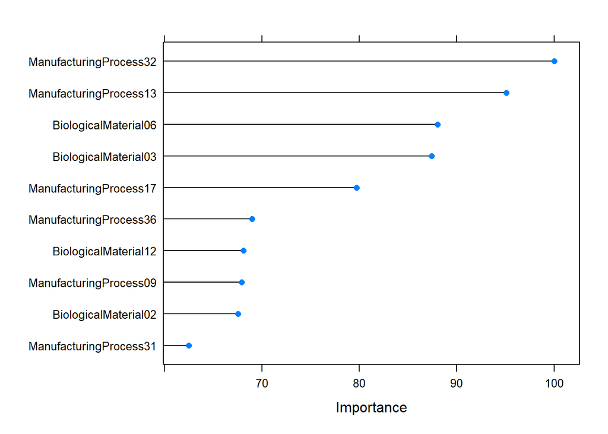

```r
plot(varImp(nnetTune), top=10)
```

**(c) Explore the relationships between the top predictors and the response for the predictors that are unique to the optimal nonlinear regression model. Do these plots reveal intuition about the biological or process predictors and their relationship with yield?**

Using the correlation matrix below, the Yield response variable doesn’t have strong correlations with many of the important predictors identified in the previous step. The strongest positive correlations are with `ManufacturingProcess32` and `ManufacturingProcess09` with correlation values 0.61 and 0.50 respectively. The strongest negative correlations are with `ManufacturingProcess36` and `ManufacturingProcess13` with correlations values -0.53 and -0.50, respectively. The response variable Yield does not have strong correlations with the important Biological Material predictors identified in the previous step.

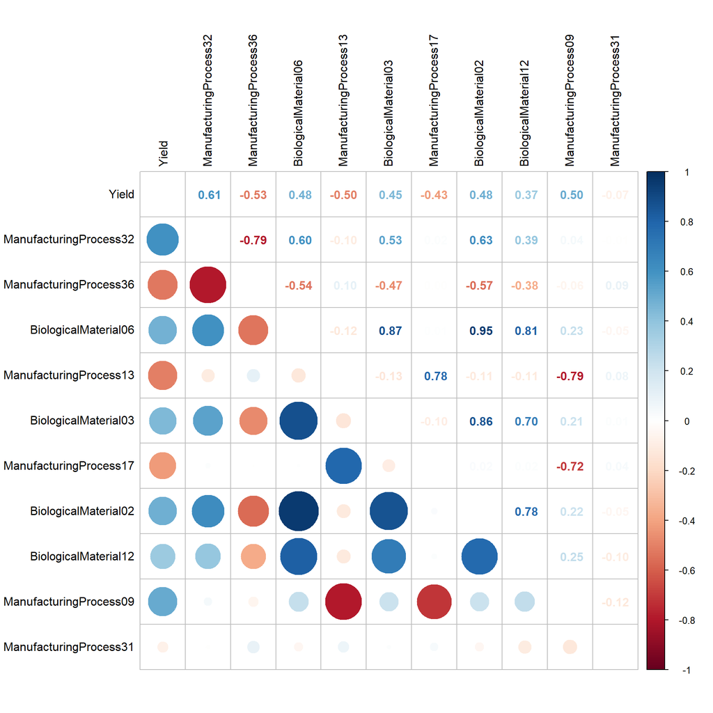

```r
corr_vals <- chem_data %>%
  dplyr::select('Yield', 'ManufacturingProcess32','ManufacturingProcess36',
         'BiologicalMaterial06','ManufacturingProcess13',
         'BiologicalMaterial03','ManufacturingProcess17',
         'BiologicalMaterial02','BiologicalMaterial12',
         'ManufacturingProcess09','ManufacturingProcess31')

corr_plot_vals <- cor(corr_vals)

corrplot.mixed(corr_plot_vals, tl.col = 'black', tl.pos = 'lt',
         upper = "number", lower="circle")
```